# Generalized Linear Models

Kevin Donovan

February 28, 2021

# Introduction

**Recall**: Discussed association analyses with correlation and linear regression

$$\begin{align}
&Y=\beta_0+\beta_1X_1+\ldots+\beta_pX_p+\epsilon \\
&\\
&\text{where E}(\epsilon)=0 \text{; Var}(\epsilon)=\sigma^2 \\
&\epsilon_i \perp \epsilon_j \text{ for }i\neq j; X_1,\ldots,X_p\perp \epsilon
\end{align}$$

- What about for discrete outcomes and non-normal error terms?

# Generalized linear model

- **Idea**: Create more general model structure to handle many distributions for outcome and residuals
- Keep flexibility and interpretability of linear regression model
  - Especially flexibility with predictors/covariates (allow continuous, categorical, transformations, etc.)
- Such a structure referred to as *generalized linear models* or GLMs
- Focus on distribution of **outcome** instead of disribution of residuals

# Regression for binary outcomes

- Suppose we want to assess association between binary outcome and predictors
  - Ex. Autism (ASD) diagnosis
- What if we use a linear regression model?
  - $ASD=\beta_0+\beta_1X_1+\ldots+\beta_pX_p+\epsilon$
  - $E(ASD|X)=\beta_0+\beta_1X_1+\ldots+\beta_pX_p$
- For binary $Y$, $\text{E}(Y|X)=\text{Pr}(Y=1|X)$
  - $\rightarrow \text{Pr}(ASD=\text{Yes}|X)=\beta_0+\beta_1X_1+\ldots+\beta_pX_p$
- Denoted *linear probability model*
  - **Limitation**: $0 \leq\text{Pr}(Y=1|X) \leq 1$ but linear function not constrained

# Logistic regression

- Specify transformation of probability which is **not constrained**, use linear model
- **Model**: Single Feature $X$
  - $\text{logit}[p(ASD=\text{Yes}|X)]=\beta_0+\beta_1X$
  - $\text{logit}(p)=\text{ln}(\frac{p}{1-p})=\text{log}( \text{odds}[p(Y=1|X)])$
  - This, modeling **log odds** as a linear function of predictors **not probability**
- **In terms of conditional probability**:
  - $p(ASD=\text{Yes}|X)=\frac{e^{\beta_0+\beta_1X}}{1+e^{\beta_0+\beta_1X}}$
  - Can transform logit model to represent probabilities of interest

# Logistic regression

- Visualization between probability $p$ and $\text{logit}(p)$

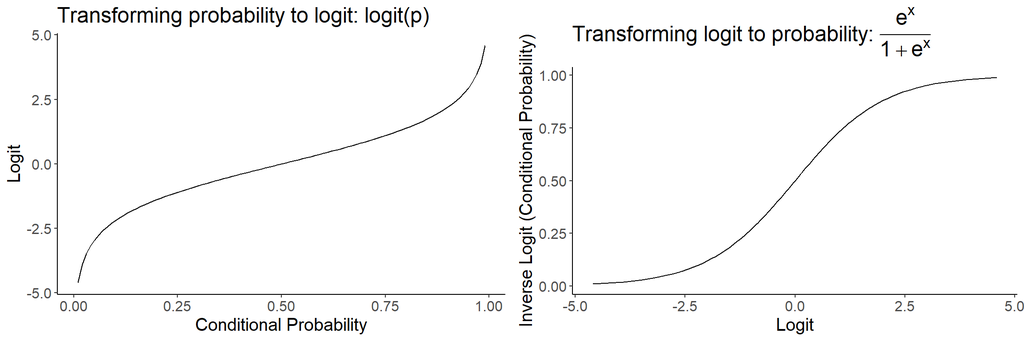

# Logistic regression

- Visualization between probability $p$ and $\text{logit}(p)$ modeling ASD diagnosis

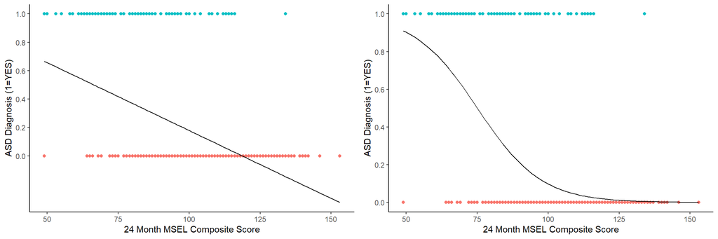

# Model fitting

- Since distribution of outcome based on covariates directly modeled, use *maximum likelihood* instead of least squares from before

# Maximum likelihood example

- **Intuition**:
  - Find estimates of $\beta$ which best match with observed data, assuming data generated from **specified likelihood**
  - Specifying the likelihood directly makes calculations more feasible, but assumptions **may not hold** (more on this later)
  - Fitting in `R`: `glm` function

```
##
## Call:
## glm(formula = factor(SSM_ASD_v24) ~ `V24 mullen,composite_standard_score`,
##     family = binomial(), data = ibis_data)
##
## Deviance Residuals:
##     Min       1Q   Median       3Q      Max
## -2.1954  -0.5375  -0.3091  -0.1466   3.2387
##
## Coefficients:
##                                        Estimate Std. Error z value Pr(>|z|)
## (Intercept)                            6.671167   0.827694    8.06 7.63e-16 ***
## `V24 mullen,composite_standard_score` -0.088884   0.009268   -9.59  < 2e-16 ***
## ---
## Signif. codes:  0 '***' 0.001 '**' 0.01 '*' 0.05 '.' 0.1 ' ' 1
##
## (Dispersion parameter for binomial family taken to be 1)
##
##     Null deviance: 514.73  on 572  degrees of freedom
## Residual deviance: 368.89  on 571  degrees of freedom
##   (14 observations deleted due to missingness)
## AIC: 372.89
##
## Number of Fisher Scoring iterations: 6
```

| Variable | Estimate | Std. Error | Z Statistic | P-value |
| --- | --- | --- | --- | --- |
| Intercept | 6.671 | 0.8277 | 8.1 | <0.005 |
| 24 Month MSEL Composite Standard Score | -0.089 | 0.0093 | -9.6 | <0.005 |

# Logistic regression

**Estimated model**: $\hat{\text{Pr}}[ASD=\text{YES}|MSEL]=\frac{e^{6.67-0.09MSEL}}{1+e^{6.67-0.09MSEL}}$

**Interpretation**:

1. $\hat{\beta_0}=6.67$
- $\hat{\text{Pr}}[ASD=\text{YES}|MSEL=0]=\frac{e^{6.67}}{1+e^{6.67}}$
2. $\hat{\beta_1}=-0.09$
- $\rightarrow$ Probability of ASD diangosis **decreases** as MSEL **increases**

# Logistic regression

**Intercept**:

- MSEL = 0 doesn’t make sense

**Solution**: center at means

- MSEL - $\mu$ = 0 $\rightarrow$ MSEL = $\mu$

```
##
## Call:
## glm(formula = factor(SSM_ASD_v24) ~ mullen_center, family = binomial(),
##     data = ibis_data)
##
## Deviance Residuals:
##     Min       1Q   Median       3Q      Max
## -2.1954  -0.5375  -0.3091  -0.1466   3.2387
##
## Coefficients:
##                Estimate Std. Error z value Pr(>|z|)
## (Intercept)   -2.336873   0.180835  -12.92   <2e-16 ***
## mullen_center -0.088884   0.009268   -9.59   <2e-16 ***
## ---
## Signif. codes:  0 '***' 0.001 '**' 0.01 '*' 0.05 '.' 0.1 ' ' 1
##
## (Dispersion parameter for binomial family taken to be 1)
##
##     Null deviance: 514.73  on 572  degrees of freedom
## Residual deviance: 368.89  on 571  degrees of freedom
##   (14 observations deleted due to missingness)
## AIC: 372.89
##
## Number of Fisher Scoring iterations: 6
```

| Variable | Estimate | Std. Error | Z Statistic | P-value |
| --- | --- | --- | --- | --- |
| Intercept | -2.337 | 0.1808 | -12.9 | <0.005 |
| 24 Month MSEL Composite Centered | -0.089 | 0.0093 | -9.6 | <0.005 |

**Interpretation**:

1. $\hat{\beta_0} = -2.34$

$$\hat{\text{Pr}}[ASD=\text{YES}|MSEL=\mu]=\frac{e^{-2.34}}{1+e^{-2.34}}$$

Slope $\hat{\beta_1}$ not changed

# Logistic Regression

Model-based estimated probabilities (non-centered):

$$\hat{\text{Pr}}[ASD=\text{YES}|MSEL=90]=\frac{e^{6.67-0.09*90}}{1+e^{6.67-0.09*90}}=0.19$$

Based on $\hat{\text{Pr}}[ASD=\text{YES}|MSEL=90]$ can create predicted response $\hat{ASD}$ by thresholding

# Logistic regression: confounding

**Example**: Credit Card Default Rate

- Consider predicting if a person defaults on their loan based on
  - Student Status (Student or Not Student):

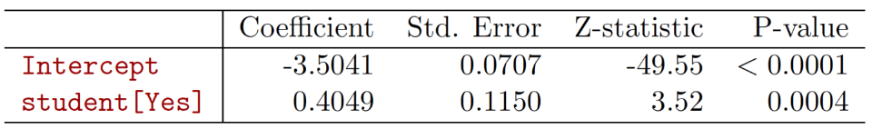

- Now consider adding features: `credit balance` and `income`

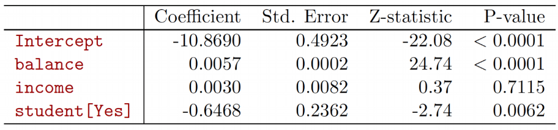

- Why did `student`’s coefficient change so much? **Confounding**

# Logistic regression: confounding

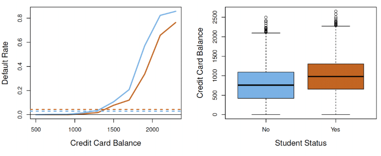

- Being a student $\rightarrow$ higher balance (more loans)
  - $\rightarrow$ higher marginal default rate vs non-students
  - But is it the higher balance or simply them being students leading to defaulting more often?
  - Need to compare students and non-students **controlling** for balance to answer this
  - Can be done using regression

# Generalized linear models

- Logistic regression one example of a GLM

**Structure of model**:

1. Choose conditional distribution $f(y|x)$
- Linear regression: $f(y|x)\sim \text{Normal}(\mu_{y|x}, \sigma^2)$
  - $\mu_{y|x} = \text{E}(Y|X); \sigma^2=\text{Var}(Y|X)=\text{Var}(\epsilon)$
- Logistic regression: $f(y|x)\sim \text{Binomial}[p(x)]$
  - $p(x) = \mu_{y|x} = \text{Pr}(Y=1|X)$

# Generalized linear models

2. Choose *link function* $g(\mu_{y|x})=\beta_0+\beta_1X_1+\ldots+\beta_pX_p$
- Linear regression: $g(\mu_{y|x})=\mu_{y|x}$
- Logistic regression $g(\mu_{y|x})=\log(\frac{\mu_{y|x}}{1-\mu_{y|x}})$
- **Idea**: $g(\mu_{y|x}):\mathcal{X}_\mu \rightarrow (-\infty, \infty)$
3. Construct likelihood and fit
- Assuming independent observations:
  - $f(y|x)=\prod_{i=1}^{n} f(y_i|x_i)$

# Generalized linear models

- Examples include
  - Poisson regression (outcome is a count)
  - Gamma regression (outcome is skewed and non-negative)
  - Multinomial logistic (categorical outcome, 2+ categories)
  - Beta, negative binomial, etc.
- Most can be fit all using the `glm`() function in R
  - some, like beta, negative binomial, *overdispered* Poisson, etc. require other packages